```python
import pandas as pd
from matplotlib import pyplot as plt
import seaborn as sns
import numpy as np
```

# 1. Use proper visualization tool to find which ethnicity group carries the highest amount of debt. Explain the results (20 points).

```python
# The result shows that the ethnicity of 'Others' carries the highest amount of debt.
```

```python
df = pd.read_csv('/content/clean_dataset.csv')
df.head()
```

|  | Gender | Age | Debt | Married | BankCustomer | Industry | Ethnicity | YearsEmployed | PriorDefault | Employed | CreditScore | DriversLicense | Citizen | ZipCode | Income | Approved |
| --- | --- | --- | --- | --- | --- | --- | --- | --- | --- | --- | --- | --- | --- | --- | --- | --- |
| 0 | 1 | 30.83 | 0.000 | 1 | 1 | Industrials | White | 1.25 | 1 | 1 | 1 | 0 | ByBirth | 202 | 0 | 1 |
| 1 | 0 | 58.67 | 4.460 | 1 | 1 | Materials | Black | 3.04 | 1 | 1 | 6 | 0 | ByBirth | 43 | 560 | 1 |
| 2 | 0 | 24.50 | 0.500 | 1 | 1 | Materials | Black | 1.50 | 1 | 0 | 0 | 0 | ByBirth | 280 | 824 | 1 |
| 3 | 1 | 27.83 | 1.540 | 1 | 1 | Industrials | White | 3.75 | 1 | 1 | 5 | 1 | ByBirth | 100 | 3 | 1 |
| 4 | 1 | 20.17 | 5.625 | 1 | 1 | Industrials | White | 1.71 | 1 | 0 | 0 | 0 | ByOtherMeans | 120 | 0 | 1 |

```python
df['Ethnicity'].value_counts()
```

```
Ethnicity
White     408
Black     138
Asian      59
Latino     57
Other      28
Name: count, dtype: int64
```

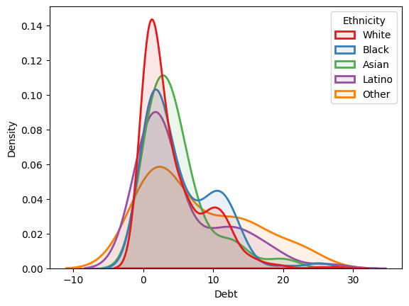

```python
sns.kdeplot(data=df, x='Debt', hue='Ethnicity',
             palette='Set1', common_norm=False, fill=True, alpha=0.1,
            linewidth=2)
plt.show()
```

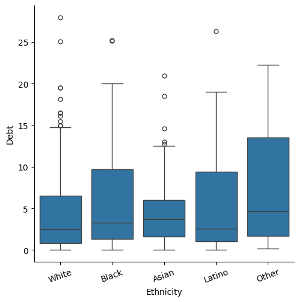

```python
sns.catplot(data=df, x='Ethnicity', y='Debt', kind='box')
plt.xticks(rotation=20)
plt.show()
```

# 2. Let's say we want to explore the length of working experience can influence the debt amount. Please use proper visualization tool we learned from this class to conduct this exploration (20 points)

```python
# The graph shows that the relationship between working experience does not strongly influence the debt amount.
# It shows that the amount of debt tends to increase as years of employed increase, but not many cases.
```

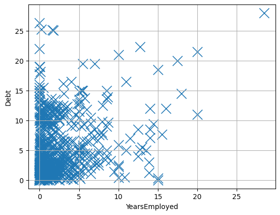

```python
sns.scatterplot(data=df, x='YearsEmployed', y='Debt',
                marker='x', s=200, palette={'female':'#f15bb5', 'male':'green'})
plt.grid(True)
plt.show()
```

# 3. Select a proper visualization tool we learned in this class to explore the relationship among

# debt, yearsemployed, creditscore, and the card approving status. Please use one single graph to express such information. Once done, please interpret your results (20 points).

```python
# The graph shows that regardless of the debt amount they have, the more experience they have, more chance of approval rate.
```

```python
import pandas as pd
import seaborn as sns
import matplotlib.pyplot as plt
import numpy as np
```

```python
df.head()
```

|  | Gender | Age | Debt | Married | BankCustomer | Industry | Ethnicity | YearsEmployed | PriorDefault | Employed | CreditScore | DriversLicense | Citizen | ZipCode | Income | Approved |
| --- | --- | --- | --- | --- | --- | --- | --- | --- | --- | --- | --- | --- | --- | --- | --- | --- |
| 0 | 1 | 30.83 | 0.000 | 1 | 1 | Industrials | White | 1.25 | 1 | 1 | 1 | 0 | ByBirth | 202 | 0 | 1 |
| 1 | 0 | 58.67 | 4.460 | 1 | 1 | Materials | Black | 3.04 | 1 | 1 | 6 | 0 | ByBirth | 43 | 560 | 1 |
| 2 | 0 | 24.50 | 0.500 | 1 | 1 | Materials | Black | 1.50 | 1 | 0 | 0 | 0 | ByBirth | 280 | 824 | 1 |
| 3 | 1 | 27.83 | 1.540 | 1 | 1 | Industrials | White | 3.75 | 1 | 1 | 5 | 1 | ByBirth | 100 | 3 | 1 |
| 4 | 1 | 20.17 | 5.625 | 1 | 1 | Industrials | White | 1.71 | 1 | 0 | 0 | 0 | ByOtherMeans | 120 | 0 | 1 |

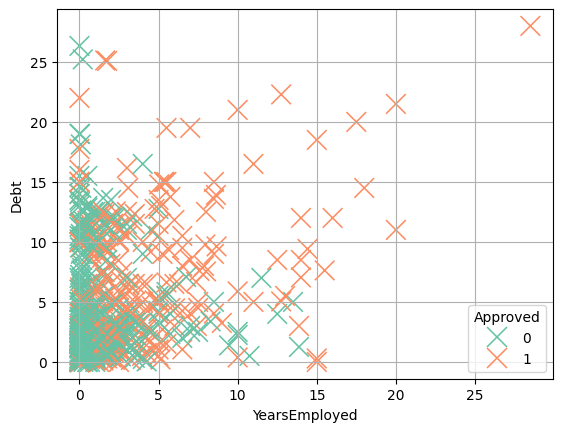

```python
sns.scatterplot(data=df, x='YearsEmployed', y='Debt', hue='Approved',
                marker='x', s=200, palette='Set2')
plt.grid(True)
plt.show()
```

# 4. Let's say Daniel carries 900 debt, his credit score is 800, and his income is 1000. Select a proper visualization you learned from this class to express such information (10 points).

```python
import pandas as pd
import numpy as np
import matplotlib.pyplot as plt
```

```python
circle = np.linspace(0,2*np.pi, 3, endpoint=False). tolist()
circle
```

```
[0.0, 2.0943951023931953, 4.1887902047863905]
```

```python
closed_circle = [0.0,2.0943951023931953, 4.1887902047863905, 0.0]
closed_circle = circle.copy()
closed_circle.append(0.0)
closed_circle
```

```
[0.0, 2.0943951023931953, 4.1887902047863905, 0.0]
```

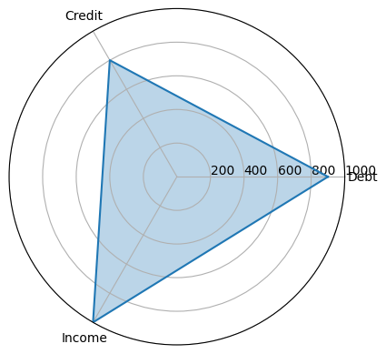

```python
Tests = ['Debt', 'Credit', 'Income']
values = [900, 800, 1000]
closed_value = [900, 800, 1000, 900]
ax = plt.subplot(polar=True)
plt.xticks(circle, Tests)
ax.set_rlabel_position(0)
plt.yticks([200, 400 , 600, 800, 1000], ['200', '400', '600', '800', '1000'])
plt.ylim(0, 1000)
ax.plot(closed_circle, closed_value)
ax.fill(closed_circle, closed_value, alpha=0.3)
plt.show()
```

# 5. Let's create a 2D random walk with 200 steps in a 2D coordinate system. Each step on y-axis follows the normal distribution. Each step on x-axis follows an exponential distribution. You can use np.random.exponential() function to construct these steps. The exponential function contains two arguments: size of the steps (just like the normal distribution function we learned) and scale. You can set the scale = 1 (20 points).

```python
import pandas as pd
import matplotlib.pyplot as plt
import numpy as np
import seaborn as sns

from sklearn import linear_model
from sklearn.metrics import mean_squared_error, r2_score
from sklearn.model_selection import train_test_split
```

```python
x = df[['YearsEmployed']]
y = df[['Debt']]
```

```python
x_train, x_test, y_train, y_test = train_test_split(x, y, test_size=0.1)
```

```python
regr = linear_model.LinearRegression()
regr.fit(x_train, y_train)
```

```
LinearRegression()
```

```python
y_pred = regr.predict(x_test)
y_pred
```

```
array([[ 4.4120875 ],
       [ 3.71078848],
       [ 3.82767165],
       [ 5.34715286],
       [ 3.76923007],
       [ 4.10117827],
       [ 6.12559477],
       [ 4.8398799 ],
       [ 7.68481626],
       [ 3.94455482],
       [ 3.76923007],
       [ 4.29520433],
       [ 4.64585384],
       [ 4.87962018],
       [ 4.87962018],
       [ 3.75052876],
       [ 4.56871095],
       [ 6.04845188],
       [ 3.84637296],
       [ 4.52897067],
       [ 3.78793138],
       [ 4.06143799],
       [ 4.87962018],
       [ 3.78793138],
       [ 4.3933862 ],
       [ 7.9185826 ],
       [ 3.71078848],
       [ 3.75052876],
       [ 4.76273701],
       [ 4.78143832],
       [ 3.78793138],
       [ 3.71078848],
       [10.72377867],
       [ 6.28221822],
       [ 3.94455482],
       [ 3.71078848],
       [ 3.71078848],
       [ 4.87962018],
       [ 4.06143799],
       [ 8.13364763],
```

[output cut: 14 more lines]

```
       [ 7.45104992],
       [ 3.76923007],
       [ 3.72948979],
       [ 5.81468554],
       [ 3.71078848],
       [ 3.76923007],
       [ 8.38611528],
       [ 4.17832116],
       [ 4.76273701],
       [ 3.84637296],
       [10.19780441],
       [ 3.72948979],
       [ 3.78793138],
       [ 4.06143799],
       [ 4.64585384]])
```

```python
y_test
```

|  | Debt |
| --- | --- |
| 352 | 11.500 |
| 405 | 6.000 |
| 280 | 0.875 |
| 642 | 0.750 |
| 273 | 10.125 |
| ... | ... |
| 365 | 1.250 |
| 427 | 0.835 |
| 335 | 0.750 |
| 554 | 11.250 |
| 143 | 11.000 |

69 rows × 1 columns

```python
np.sqrt(mean_squared_error(y_test, y_pred))
```

```
4.923311289885532
```

```python
r2_score(y_test, y_pred)
```

```
0.013426563501647282
```

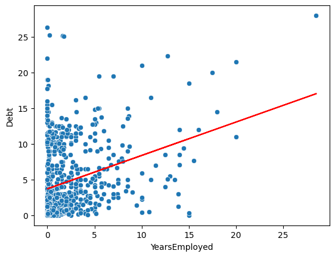

```python
sns.scatterplot(data=df, x='YearsEmployed', y='Debt')
plt.plot(x_train, regr.predict(x_train), color='red')
plt.show()
```

```python
print('slope:', regr.coef_)
print('intercept:', regr.intercept_)
```

```
slope: [[0.46753268]]
intercept: [3.71078848]
```

```python
n_steps = 200
x_steps = np.random.exponential(size = n_steps)
y_steps = np.random.normal(size = n_steps)
```

```python
x = np.cumsum(x_steps)
y = np.cumsum(y_steps)
```

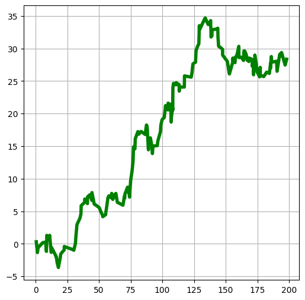

```python
plt.figure(figsize=(6, 6))
plt.plot(x, y, color='green', linewidth=4)
plt.grid(True)
plt.show()
```

```python
!jupyter nbconvert --to html BANA310_HW4.ipynb
```